# BIOINF703 Lab 2

Badi James

August 14, 2018

## Plotting G

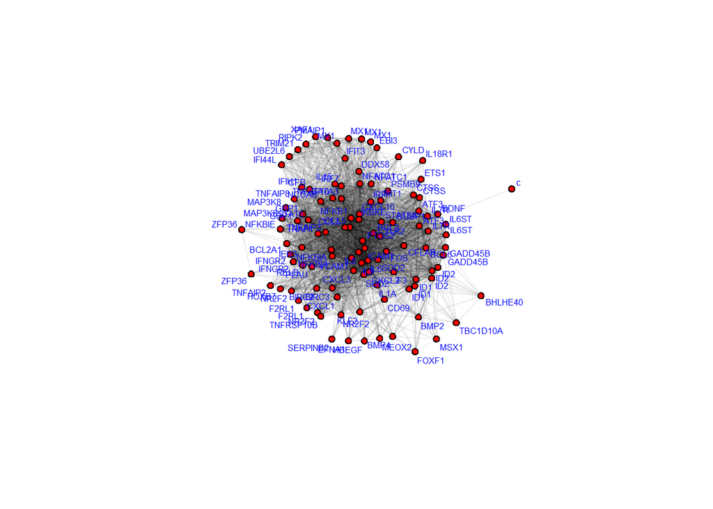

```r
vTidy <- sapply(vNames, function(x) unlist(strsplit(x, "_"))[1])

plot.network(G, mode = "kamadakawai", edge.col = rgb(red = 0, blue = 0, green = 0, alpha = 0.05), label = vTidy, label.cex = 0.5, label.col = "blue")
```

This visualization of the network shows with some clarity the conections between the vertexes on the outside of the plot. However for the center of the plot the edges are indistinguishable. This does provide an overall picture of the complexity of the network but does not provide usefull information on the specific connections. A better approach would be to seperate the network into subnetworks. As this is a gene interaction network, the graph could be divided by different known cellular signalling pathways, etc.

## Plotting degree

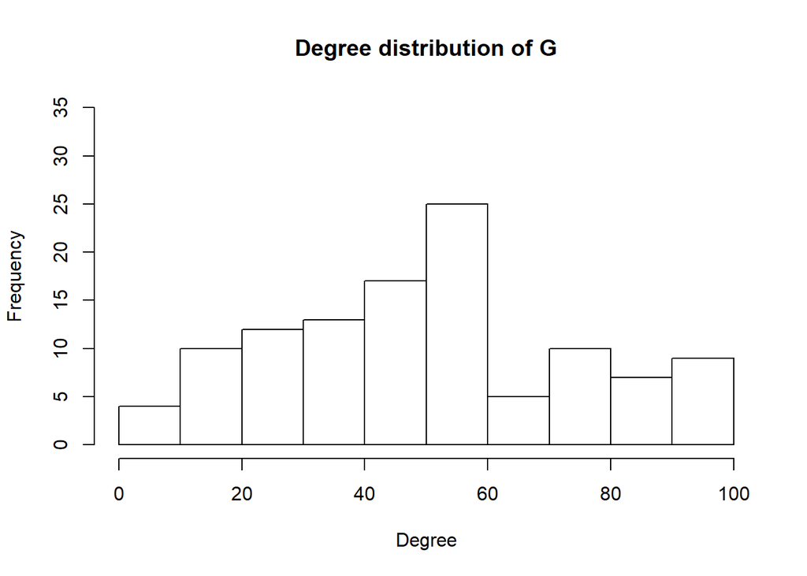

```r
gNodeDegs <- degree(G, gmode = "graph")
hist(gNodeDegs, ylim = c(0,35), xlim = c(0,100), xlab = "Degree", main = "Degree distribution of G")
```

## Binomial (Simulating an Erdos-Renyi model for G)

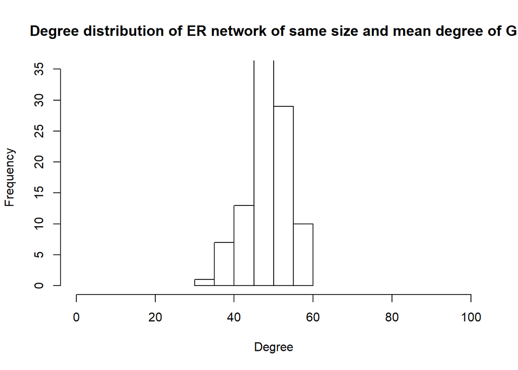

```r
gDegMean <- mean(gNodeDegs)
n <- length(gNodeDegs)
prob <- gDegMean / (n-1)
binomDegs <- rbinom(n, n-1, prob)
hist(binomDegs, ylim = c(0,35), xlim = c(0,100), xlab = "Degree",
     main = "Degree distribution of ER network of same size and mean degree of G")
```

G has a broad range of degree values. Variance is high, so many degree values are not clustered around the mean. As an ER network of the same size and mean degree has a narrower range of degree values clustered around the mean it is not a representative model of G. It is missing nodes of very low and very high degree, unlike G.

## scale free degree

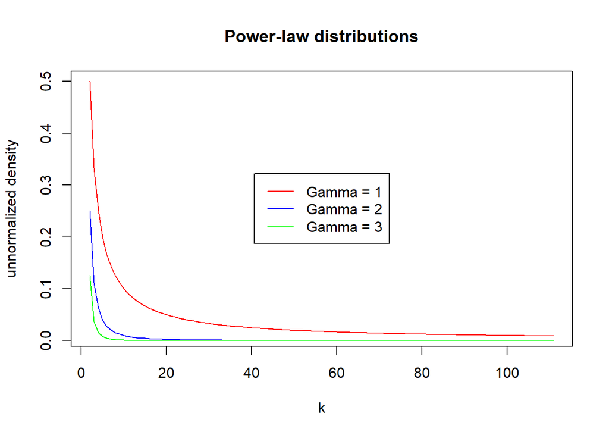

```r
k = 2:(n-1)
unnormDensGam1 <- k^(-1)
unnormDensGam2 <- k^(-2)
unnormDensGam3 <- k^(-3)

plot(k,unnormDensGam1, type= "l", ylab = "unnormalized density", col="red",
     main = "Power-law distributions")
lines(k, unnormDensGam2, col="blue")
lines(k, unnormDensGam3, col="green")
legend("center", legend = c("Gamma = 1", "Gamma = 2", "Gamma = 3"), col= c("red", "blue", "green"), lty = c(1,1,1))
```

Scale free networks would be poor models for G as the high frequency of nodes with low degree is not characteristic of G. Out of the gamma values plotted above, a scale free network with gamma of 1 would be the best of the 3 scale free networks for modelling G as it has the higher frequency of nodes with higher degree.

## Making 200 ER graphs

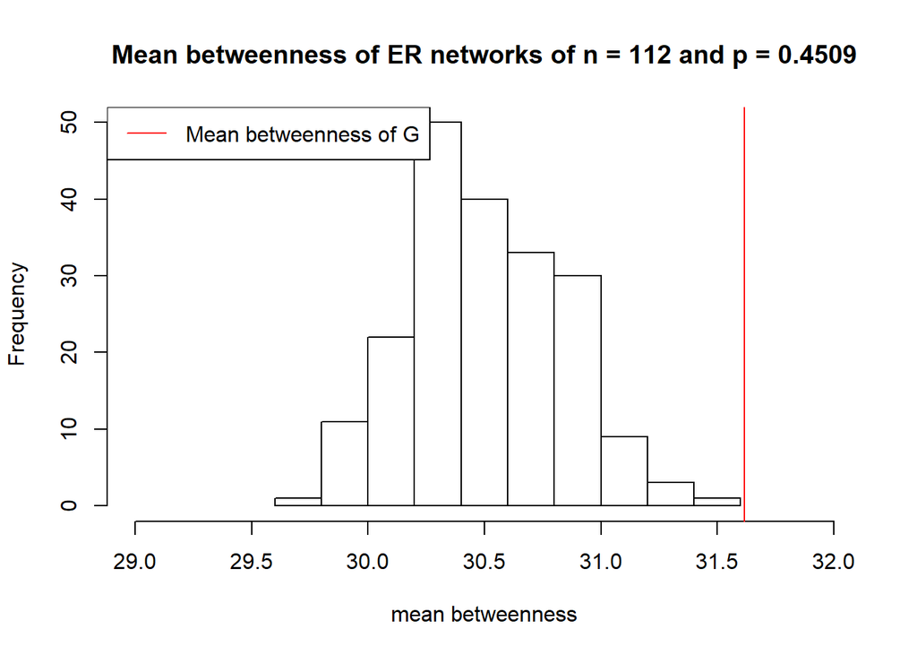

```r
er200 <- sapply(rep(n, 200), function(x) list(sampleER(x, prob)))
er200Btwn <- sapply(er200, betweenness, gmode = "graph", cmode = "undirected")
er200MeanBtwn <- apply(er200Btwn, 2, mean)
gBetween <- betweenness(G, gmode = "graph", cmode = "undirected")
gMeanBtwn <- mean(gBetween)
hist(er200MeanBtwn, xlim = c(29, 32), xlab = "mean betweenness",
     main = paste("Mean betweenness of ER networks of n =", n, "and p =", round(prob,4)))
abline(v = gMeanBtwn, col = "red")
legend("topleft", legend = c("Mean betweenness of G"), col = c("red"), lty = c(1))
```

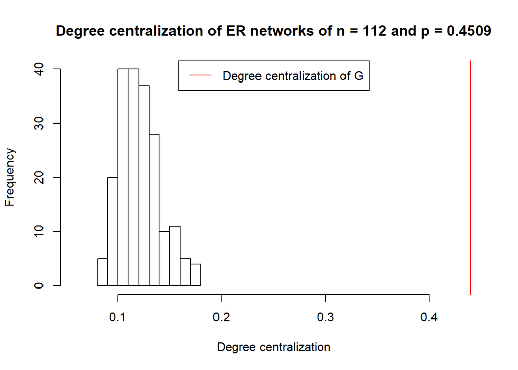

```r
er200DegCen <- sapply(er200, function(x) centralization(x, degree, mode = "graph"))
gDegCen <- centralization(G, degree, mode = "graph")
hist(er200DegCen, xlab = "Degree centralization", xlim = c(0.06, 0.44),
     main = paste("Degree centralization of ER networks of n =", n, "and p =", round(prob,4)))
abline(v = gDegCen, col = "red")
legend("top", legend = c("Degree centralization of G"), col = c("red"), lty = c(1))
```

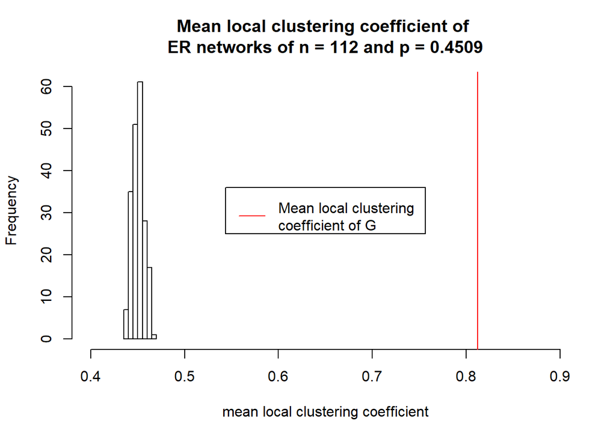

```r
er200LCC <- sapply(er200, localclustering)
gLCC <- localclustering(G)
hist(er200LCC, xlim = c(0.4,0.9), xlab = "mean local clustering coefficient",
     main = paste("Mean local clustering coefficient of \nER networks of n =", n, "and p =", round(prob,4)))
abline(v = gLCC, col = "red")
legend("center", legend = c("Mean local clustering \ncoefficient of G"), col = c("red"), lty = c(1))
```

Betweenness is a measure of node importance via how often it appears on the shortest paths between pairs of nodes in the network. $\displaystyle C_b(u) = \sum_{t,s \in V}\frac{\sigma_{st}(u)}{\sigma_{st}}$

$\sigma_{st}(u)$ = number of shortest paths from node $s$ to node $t$ that go through node u

$\sigma_{st}$ = total number of shortest paths from node $s$ to node $t$

Degree centralization is a measure of how much the degree of the nodes in a network deviate from the max degree in the network (normalised to the theoretical max degree possible).

$\displaystyle deg^*(G) = \sum_{i\in V}|\max_{v \in V}(deg(v)) - deg(i)|$

Local clustering coefficient of a node $u$ is a measure of the connectedness of the nodes in $u$’s neighbourhood. More formally it is a measure of number of edges between the nodes in $u$’s neighbourhood (not including edges with $u$) over the total number of edges possible for the neighbourhood.

From the above histograms we can see that ER is a poor model for G. The smaller variance in degree compared to G is reflected in the degree centralization histogram, with the value for G falling considerably outside the distribution of the ER values. The Mean local clustering coefficient histogram shows that G’s neighbourhoods are considerably more connected than those of a ER network. The mean betweenness of G being higher than the ER networks implies that there are less redundant shortest paths in G compared to the ER networks. The difference in values for these metrics implies G has a structure that gets lost when randomized. Genes with a specific function only involved in a specific pathway will be represented in G as a node with low degree. Likewise regulatory genes like transcription factors involved in multiple pathways would be represented as nodes of high degree. These nodes would not occur in graphs like ER where every node has roughly the same degree. How genes in the same pathways often regulate each other in various feedback loops is reflected in G’s higher than random local clustering coefficient.

## Making 200 graphs sampled from the degree distribution of G

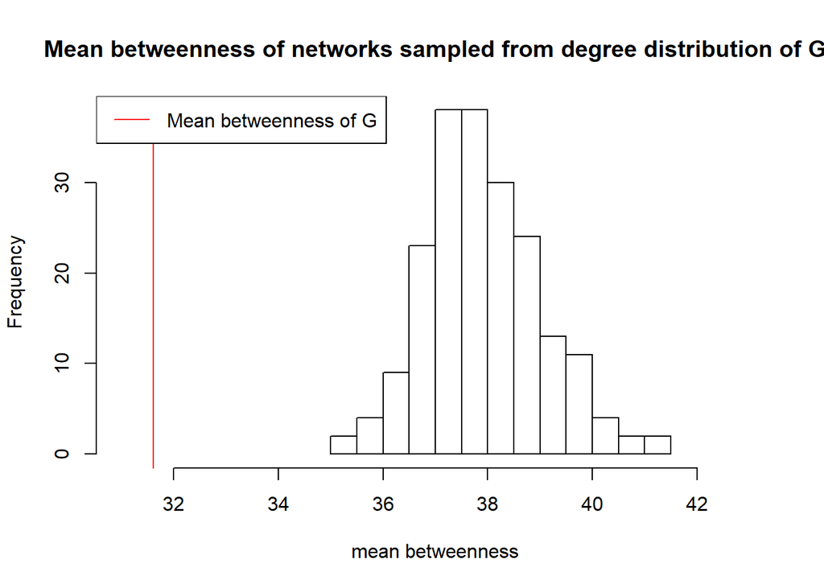

```r
dd200 <- sapply(rep(1, 200), function(x) list(rgraphFromDegreeDist(G)))
dd200Btwn <- sapply(dd200, betweenness, gmode = "graph", cmode = "undirected")
dd200MeanBtwn <- apply(dd200Btwn, 2, mean)
hist(dd200MeanBtwn, xlim = c(31, 43), xlab = "mean betweenness",
     main = paste("Mean betweenness of networks sampled from degree distribution of G"))
abline(v = gMeanBtwn, col = "red")
legend("topleft", legend = c("Mean betweenness of G"), col = c("red"), lty = c(1))
```

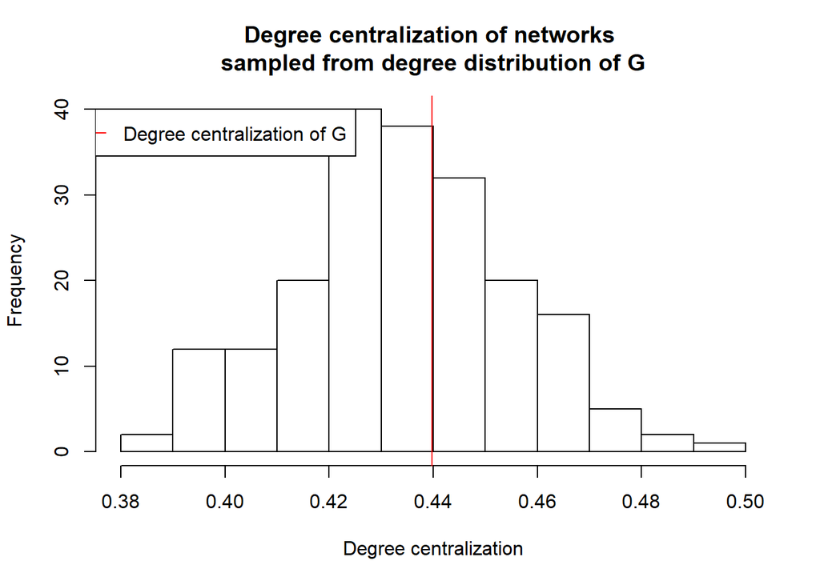

```r
dd200DegCen <- sapply(dd200, function(x) centralization(x, degree, mode = "graph"))
hist(dd200DegCen, xlab = "Degree centralization",
     main = paste("Degree centralization of networks \nsampled from degree distribution of G"))
abline(v = gDegCen, col = "red")
legend(0.367, 40, legend = c("Degree centralization of G"), col = c("red"), lty = c(1))
```

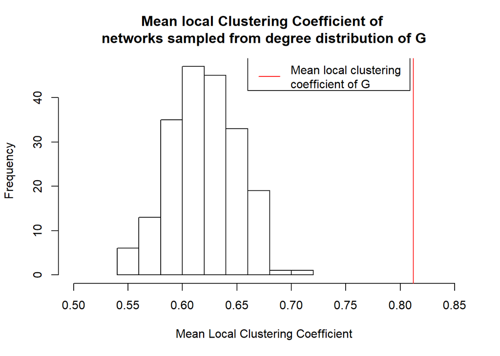

```r
dd200LCC <- sapply(dd200, localclustering)
hist(dd200LCC, xlim = c(0.5,0.85), xlab = "Mean Local Clustering Coefficient",
     main = "Mean local Clustering Coefficient of \nnetworks sampled from degree distribution of G")
abline(v = gLCC, col = "red")
legend(0.66, 50, legend = c("Mean local clustering \ncoefficient of G"), col = c("red"), lty = c(1))
```

Building a network by sampling from the degree distribution of G provides a model that is at least better than ER, but still looses the structures present in G. Unlike ER, the mean betweenness of these random graphs are all higher than that of G. This is possibly due to how G, being a natural network, would likely have intraconnected neigbourhoods representing specific pathways and a few nodes that connect the neighbourhoods to each other. The neigbourhood connecting nodes would have high betweenness but the mean value would be reduced by nodes in the neigbourhoods. This is because for a node in a neighbourhood $v$, it would be unlikely to be on the shortest path between a pair of nodes where neither node are in $v$’s neighbourhood. As a random graph would not likely share this structure nodes would more likely be on shortest paths between other nodes. The degree centralization is centered around the degree centralization of G which is to be expected when sampling from the same degree distribution. The random graphs would have max degree values similar to that of G with the other degree values deviating a similar amount. Just like with ER networks, the mean local clustering coefficient are higher than these random graphs, also potentially indicating a ‘connected intraconnected neigbourhoods’ structure. Random graphs without a bias towards connected neighbourhoods would have lower local clustering coefficient.

## If we had a good model for G

If the above historgrams were to be plotted for a good model of G, the values would be distributed around a mean equal to the values for G. A possible model to try for G would be one that, when building the network edge by edge, the probability of an edge between node $s$ and $t$ would increase depending on the size of the intersect between nodes in the neighbourhoods of $s$ and $t$. This would increase the average local clustering coefficient, hopefully better reflecting G.